# EDRM878 Assignment4

Tiejun Zhang

### 7.4. Children were asked to build towers as high as they could out of cubical and cylindrical blocks [3, 7]. The number of blocks used and the time taken were recorded (data set: blocks). In this problem, only consider the number of blocks used y and the age of the child x. In Problem 6.10, a glm was fitted for these data.

#### 1.Use a Wald test to determine if age seems necessary in the model.

```r
data(blocks)
# fit the model
m1 <- glm(Number ~ Age, data = blocks, family = poisson(link = "log"))
printCoefmat(coef(summary(m1)))
```

```
            Estimate Std. Error z value Pr(>|z|)
(Intercept)  1.34470    0.22235  6.0476 1.47e-09 ***
Age          0.14151    0.05340  2.6500  0.00805 **
---
Signif. codes:  0 ‘***’ 0.001 ‘**’ 0.01 ‘*’ 0.05 ‘.’ 0.1 ‘ ’ 1
```

The test results suggest that age is necessary in the model (z = 2.65, p = 0.008).

#### 2.Use a score test to determine if age seems necessary in the model.

```r
# library(statmod)
m0 <- glm(Number ~ 1, data=blocks, family=poisson(link = "log"))
z.stat <- glm.scoretest(m0, blocks$Age)
p.val <- 2 * pnorm(abs(z.stat), lower.tail = FALSE)
round(c(score.stat = z.stat, P = p.val), 4)
```

```
score.stat          P
    2.6523     0.0080
```

The test results also suggest that age is necessary in the model (z = 2.65, p = 0.008).

#### 3.Use a likelihood ratio test to determine if age seems necessary in the model.

```r
m0 <- glm(Number ~ 1, data = blocks, family = poisson(link = "log"))
m1 <- glm(Number~ Age, data = blocks, family = poisson(link = "log"))
anova(m1, test = "Chisq")
```

```
Analysis of Deviance Table

Model: poisson, link: log

Response: Number

Terms added sequentially (first to last)

     Df Deviance Resid. Df Resid. Dev Pr(>Chi)
NULL                    99     69.429
Age   1   7.1854        98     62.244  0.00735 **
---
Signif. codes:  0 ‘***’ 0.001 ‘**’ 0.01 ‘*’ 0.05 ‘.’ 0.1 ‘ ’ 1
```

The test results still suggest that age is necessary in the model(chisq = 7.19, p = 0.007).

#### 5.Is the saddlepoint approximation expected to be accurate? Explain.

```r
min(blocks$Number)
```

```
[1] 3
```

Yes, because the saddlepoint approximation is sufficiently accurate when min(yi) >= 3 for a Poisson distribution.

#### 6.Is the Central Limit Theorem expected to be accurate? Explain.

No, the CLT only works well when (yi) >= 5 for a Poisson distribution.

```r
confint(m1)
```

```
                2.5 %    97.5 %
(Intercept) 0.9024058 1.7742235
Age         0.0377308 0.2471074
```

#### 8.Plot the number of blocks used against age, and show the relationship described by the fitted model. Also plot the lines indicating the lower and upper 95% confidence intervals for these fitted values.

```r
new.Age <- seq( min(blocks$Age), max(blocks$Age), length = 100)
new.Num <- predict(m1,
                   se.fit = TRUE,
                   newdata = data.frame(Age = new.Age),
                   type = "response")
zstar <- qnorm(0.975)
ci.lo <- new.Num$fit - zstar * new.Num$se.fit
ci.hi <- new.Num$fit + zstar * new.Num$se.fit
plot( jitter(Number) ~ Age, data = blocks,
      las = 1,
      xlab = "Age",
      ylab = "Number of Blocks")
lines(new.Num$fit ~ new.Age, lwd = 2)
```

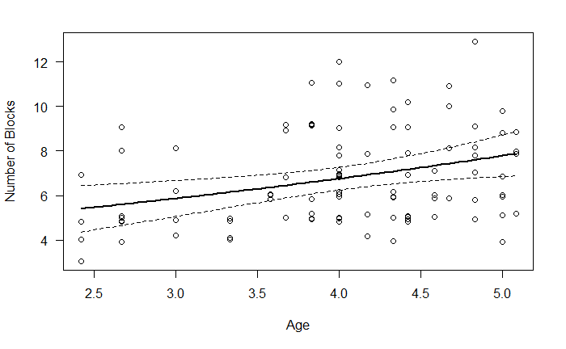

```r
lines(ci.lo ~ new.Age, lty = 2)
lines(ci.hi ~ new.Age, lty = 2)
```

The width of the interval is just a bit wider at both ends.

### 8.11. Children were asked to build towers as high as they could out of cubical and cylindrical blocks [8, 14]. The number of blocks used and the time taken were recorded (data set: blocks). In this problem, only consider the number of blocks used y and the age of the child x. In Problem 6.10, a glm was fitted for these data. Perform a diagnostic analysis, and determine if the model is suitable.

```r
# fit model
m1 <- glm(Number ~ Age, data = blocks, family = poisson(link = "log"))
```

#### Standardized residuals agianst the fitted value

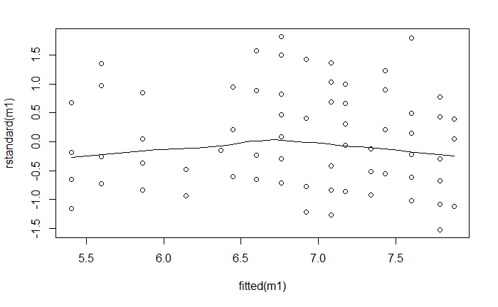

```r
scatter.smooth(rstandard(m1) ~ fitted(m1))
```

The linear relationship looks good. The variance also looks fine.

#### Q-Q plot for quantile residuals

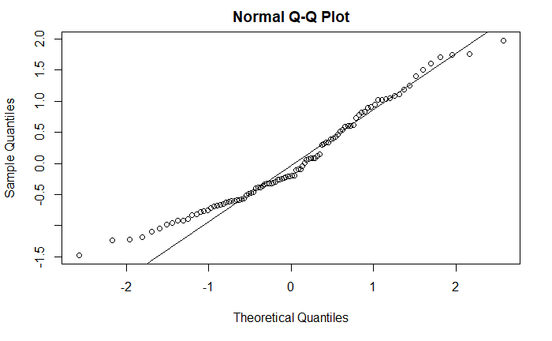

```r
qqnorm(qresid(m1))
qqline(qresid(m1))
```

#### Outliers

```r
rs <- cbind(rD = resid(m1),
            "r'D" = rstandard(m1),
            "r''" = rstudent(m1),
            rQ = qresid(m1))
head(rs)
```

[output not shown]

```r
apply(abs(rs), 2, max)
```

[output not shown]

Given a normal distribution, all three types of residuals look fine.

#### Influential Observations

```r
im <- influence.measures(m1)
names(im)
```

```
[1] "infmat" "is.inf" "call"
```

```r
im$infmat <- round(im$infmat, 3)
head(im$infmat)
```

[output not shown]

```r
colSums(im$is.inf)
```

[output not shown]

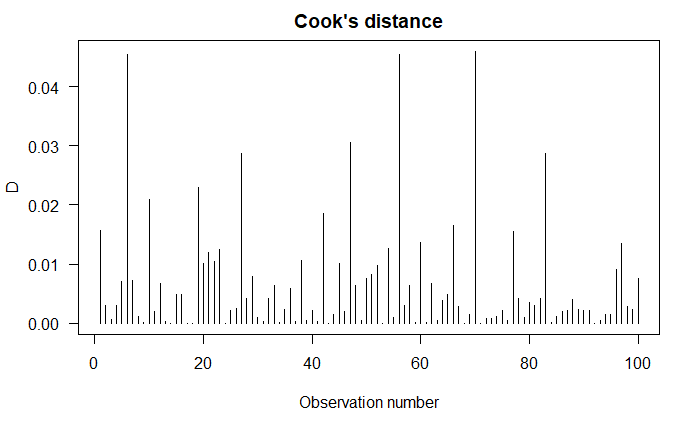

```r
#plot
plot(cooks.distance(m1), type = "h", main = "Cook's distance", ylab = "D", xlab = "Observation number", las = 1)
```

Only one method identified seven influential observations, so it shoud not be a big concern.

Overall, the disagnostic analysis suggestted that the model fits the data well but not perfect.